# Monthly Forecast

Load all necessary libraries and data sets.

```r
library(dplyr)
library(tidyr)
library(ggplot2)
library(gridExtra)
library(vars)
library(forecast)
library(fpp2)
library(lubridate)
library(scales)
library(lemon)
options(scipen=999)
library(GGally)
library(plotly)
library(seasonal)

setwd("~/Ubiqum/Project 4/Task 1/Original Data Set")
power2 <- readRDS("~/Ubiqum/Project 4/Task 1/Original Data Set/power2.rds")
```

I start by creating a data frame containing montly totals in watt-hours for each sub meter as well as a total for the entire household. I then store this as a time-series object.

```r
pMonth <- power2 %>%
  group_by(month=floor_date(DateTime, "month")) %>%
  summarize_at(vars(S1_Kitchen:S4_Rest), sum, na.rm = TRUE) %>%
  mutate(total = S1_Kitchen + S2_Laundry + S3_WH_AC + S4_Rest)

pMonthTS <- ts(pMonth, frequency = 12, start = c(2006, 12))
```

We can now plot the time series to see that there is seasonality present in the monthly household consumption totals. We can also make a seasonal plot showing the seasonal variation by year.

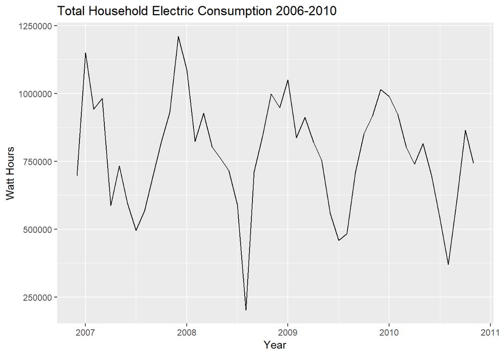

```r
autoplot(pMonthTS[,"total"]) +
  ggtitle("Total Household Electric Consumption 2006-2010") +
  xlab("Year") +
  ylab("Watt Hours")
```

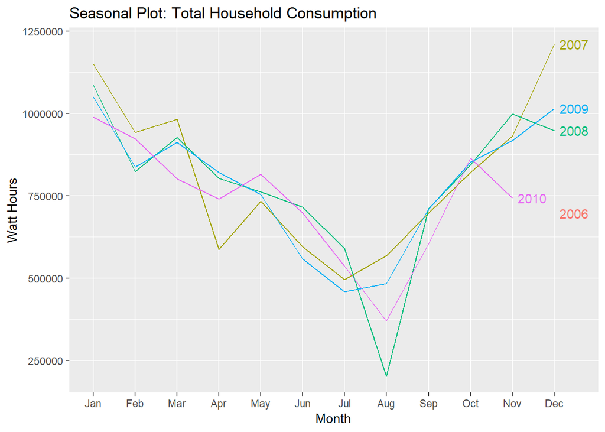

```r
ggseasonplot(pMonthTS[,"total"], year.labels=TRUE) +
  ylab("Watt Hours") +
  ggtitle("Seasonal Plot: Total Household Consumption")
```

Next, I create a lag plot as well as an autocorrelation plot to further explore seasonality in the data set.

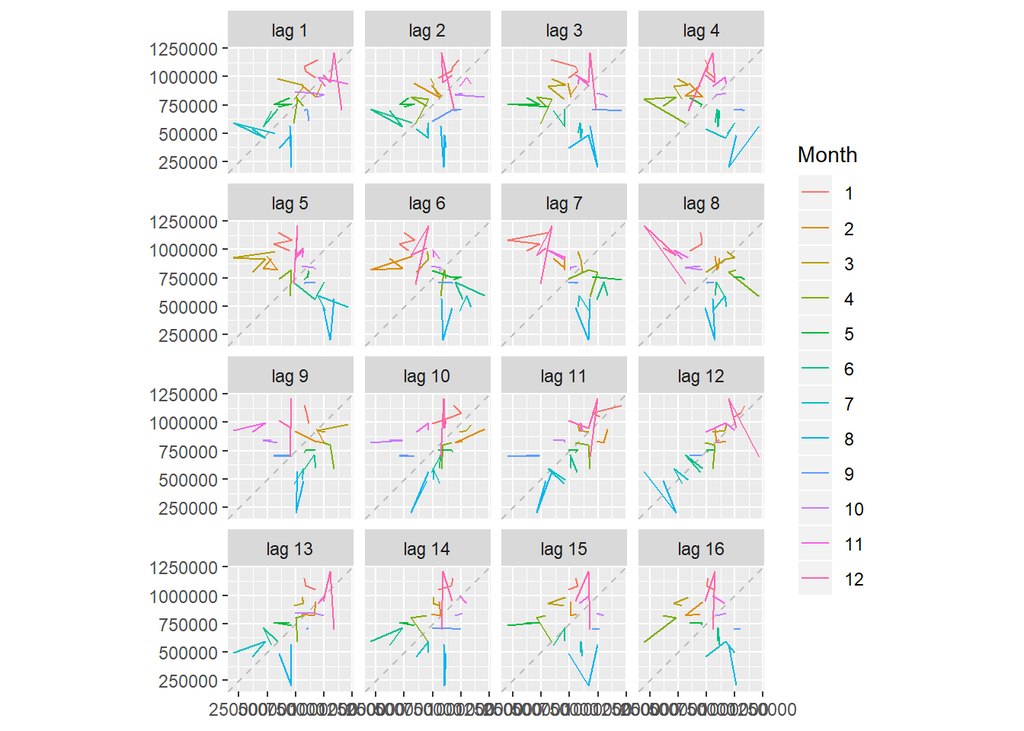

```r
gglagplot(pMonthTS[,6])
```

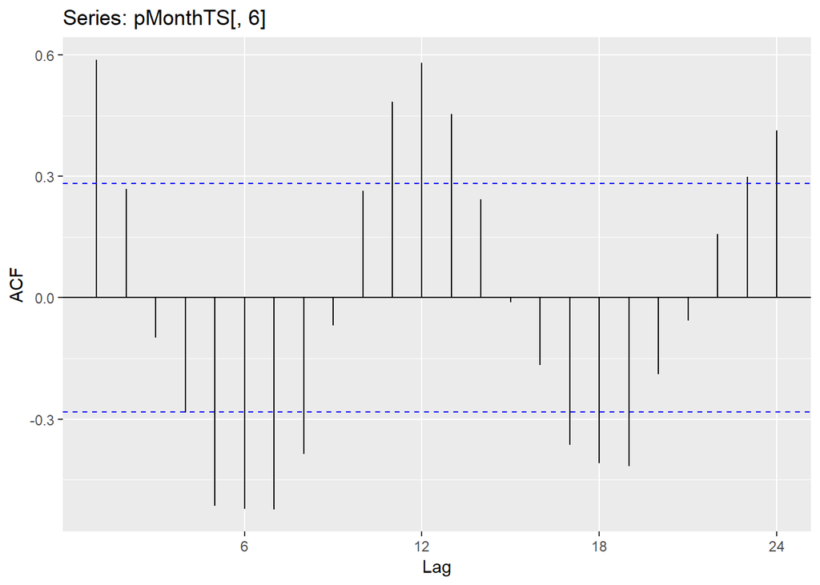

```r
ggAcf(pMonthTS[,6])
```

Using the tsclean function, we identify and replace any outliers (with suggested values) and missing values so that our model performs better.

```r
tsoutliers(pMonthTS[,6])
```

```
## $index
## [1]  1 21
##
## $replacements
## [1] 1093154  539108
```

```r
pMonthClean <- tsclean(pMonthTS[,6])
```

Now, we partition the data into a training and testing set. I want to use a full year as a testing set in order to ensure my forecast for the next 12 months is useful.

Next, I train a linear model on the testing set using trend and seasonality as predictors. I also plot the model against the original data.

```r
test1 <- window(pMonthClean,start=c(2006,12), end=c(2009,11))
rest1 <- window(pMonthClean, start=c(2009,11))

LMMonth <- tslm(test1 ~ trend + season)
summary(LMMonth)
```

```
##
## Call:
## tslm(formula = test1 ~ trend + season)
##
## Residuals:
##     Min      1Q  Median      3Q     Max
## -162169  -30766   -6109   26591  126839
##
## Coefficients:
##             Estimate Std. Error t value             Pr(>|t|)
## (Intercept)  1110092      43647  25.433 < 0.0000000000000002 ***
## trend          -1025       1189  -0.862             0.397586
## season2      -226910      57075  -3.976             0.000598 ***
## season3      -153089      57112  -2.681             0.013356 *
## season4      -355560      57174  -6.219       0.000002406984 ***
## season5      -341922      57260  -5.971       0.000004345111 ***
## season6      -467485      57371  -8.148       0.000000031244 ***
## season7      -574381      57507  -9.988       0.000000000782 ***
## season8      -557940      57666  -9.675       0.000000001420 ***
## season9      -381155      57850  -6.589       0.000001009176 ***
## season10     -247329      58057  -4.260             0.000294 ***
## season11     -136078      58288  -2.335             0.028658 *
## season12      -12847      57075  -0.225             0.823892
## ---
## Signif. codes:  0 '***' 0.001 '**' 0.01 '*' 0.05 '.' 0.1 ' ' 1
##
## Residual standard error: 69890 on 23 degrees of freedom
## Multiple R-squared:  0.9177, Adjusted R-squared:  0.8748
## F-statistic: 21.37 on 12 and 23 DF,  p-value: 0.000000001184
```

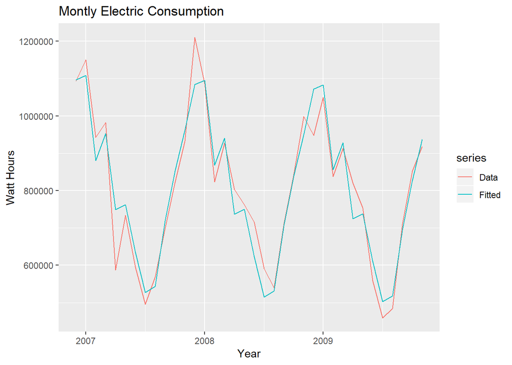

```r
autoplot(test1, series="Data") +
  autolayer(fitted(LMMonth), series="Fitted") +
  xlab("Year") +
  ylab("Watt Hours") +
  ggtitle("Montly Electric Consumption")
```

I also check the residuals and plot the errors of the model.

```r
accuracy(LMMonth)
```

```
##                               ME     RMSE      MAE        MPE     MAPE
## Training set 0.00000000001616741 55861.01 41861.81 -0.5549126 5.589059
##                   MASE
## Training set 0.2607908
```

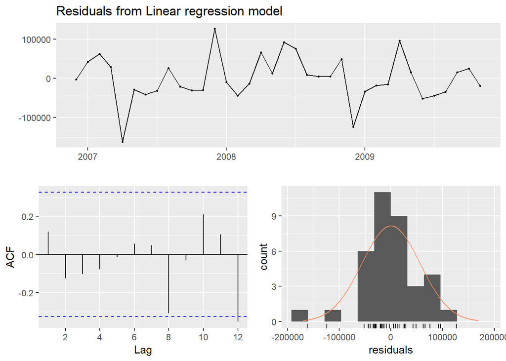

```
##
##  Breusch-Godfrey test for serial correlation of order up to 16
##
## data:  Residuals from Linear regression model
## LM test = 23.973, df = 16, p-value = 0.0901
```

```r
checkresiduals(LMMonth)
```

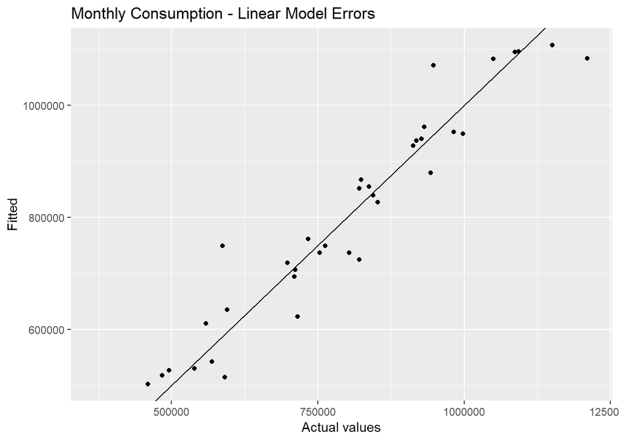

```r
cbind(Data=pMonthClean, Fitted=fitted(LMMonth)) %>%
  as.data.frame() %>%
  ggplot(aes(x = Data, y = Fitted)) +
  geom_point() +
  ylab("Fitted") + xlab("Actual values") +
  ggtitle("Monthly Consumption - Linear Model Errors") +
  geom_abline(intercept=0, slope=1)
```

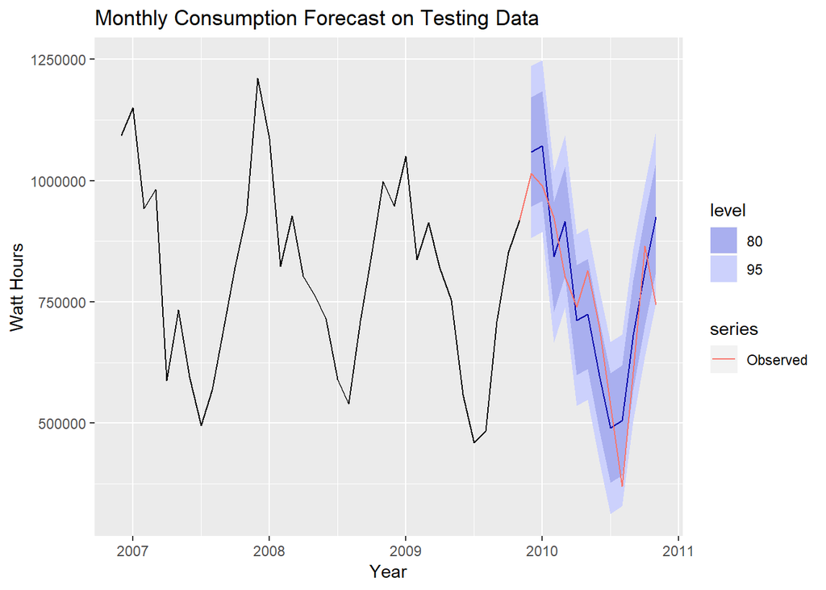

```r
LMTestfcast <- forecast(LMMonth, h=12)

autoplot(LMTestfcast, series="Forecast") +
  autolayer(rest1, series="Observed") +
  ggtitle("Monthly Consumption Forecast on Testing Data") +
  xlab("Year") + ylab("Watt Hours")
```

Finally, I deploy the model on the entire data set to forecast the next 12 months of household energy consumption.

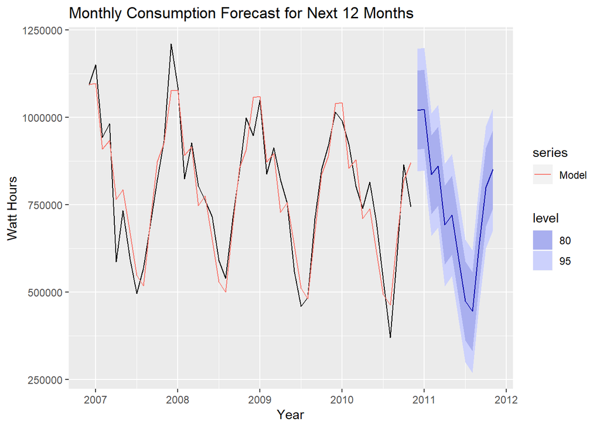

```r
LMMonthfinal <- tslm(pMonthClean ~ trend + season)
LMFinalFcast <- forecast(LMMonthfinal, h=12)

autoplot(LMFinalFcast)+
  autolayer(fitted(LMMonthfinal), series="Model") +
  ggtitle("Monthly Consumption Forecast for Next 12 Months") +
  xlab("Year") + ylab("Watt Hours")
```

Now that we have forecasted the next 12 months of energy consumption, and we know that there is trend and seasonality to the data, we can decompose the time-series data to separate out the season and the trend. This plot shows the seasonal component, the trend component, and the remainder component of the time series data set.

We see from the decomposed plot that there is siginficant seasonality, but we also see a decreasing trend which is not as easily visible from the full data set.

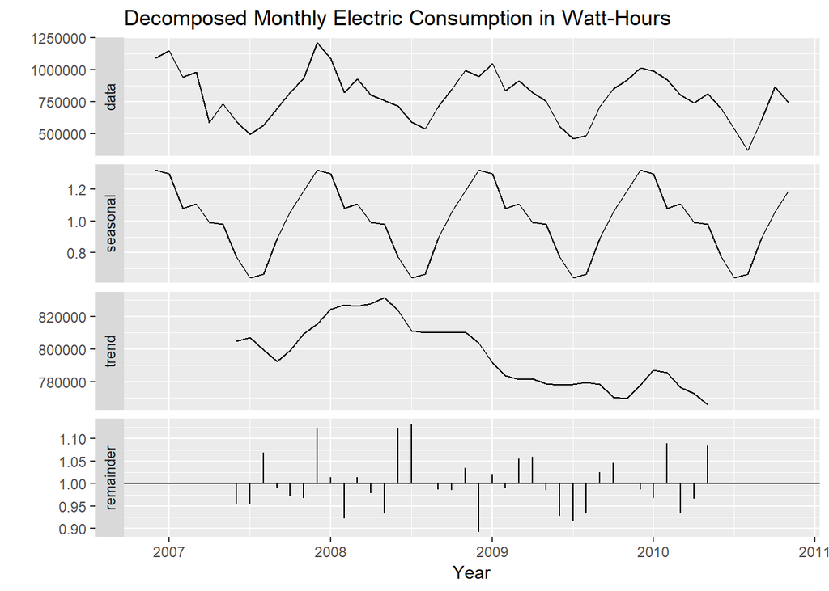

```r
pMonthD <- decompose(pMonthClean)

pMonthClean %>% decompose(type="multiplicative") %>%
  autoplot() + xlab("Year") +
  ggtitle("Decomposed Monthly Electric Consumption in Watt-Hours")
```

Next, I’ll use the Simple Exponential Smoothing (SES) model to create a model to predict monthly consumption. The prediction intervals show that there is considerable uncertainty in the future values over the next 12 months of the forecast period.

```r
sesMonth <- ses(pMonthClean, h = 12)

round(accuracy(sesMonth),2)
```

```
##                    ME     RMSE      MAE   MPE  MAPE MASE ACF1
## Training set -2490.98 150211.2 129754.8 -2.47 17.65 1.65 0.05
```

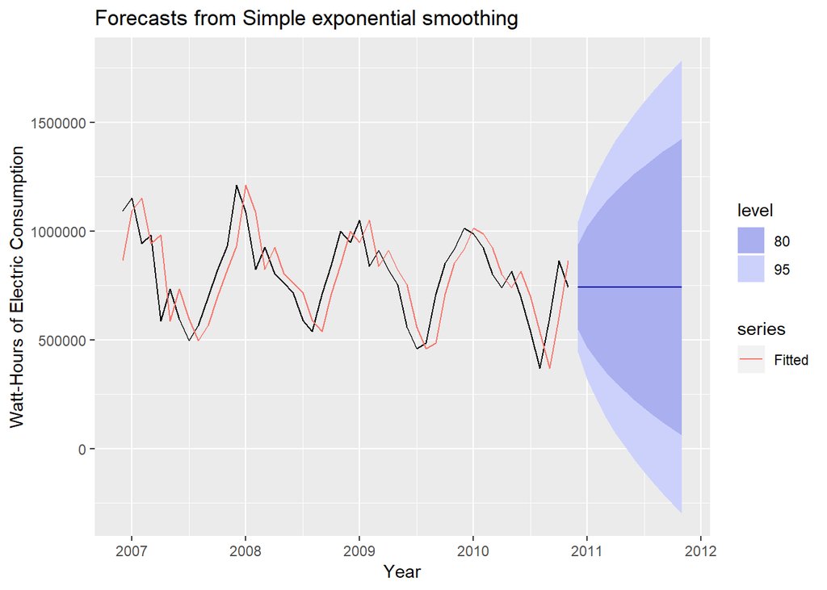

```r
autoplot(sesMonth) +
  autolayer(fitted(sesMonth), series="Fitted") +
  xlab("Year") +
  ylab("Watt-Hours of Electric Consumption")
```

Now, we’ll try the Holt Winters model using both additive and multiplicative seasonal parameters. From the summary statistics, we see that the multiplicative method performs best.

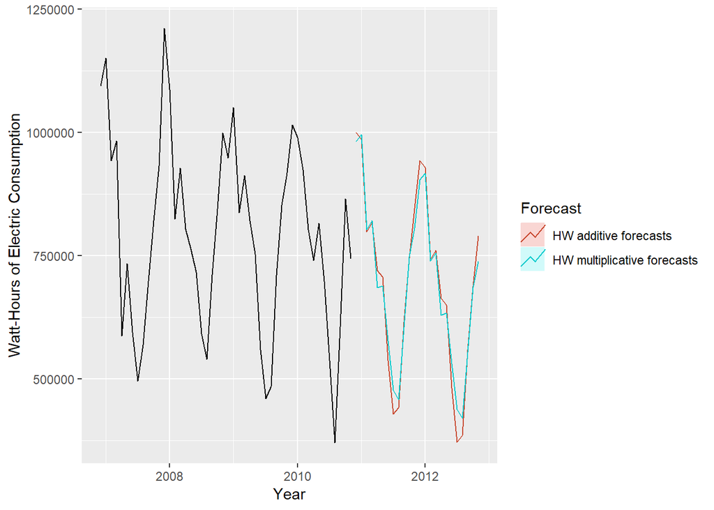

```r
fit1 <- hw(pMonthClean,seasonal="additive")
fit2 <- hw(pMonthClean,seasonal="multiplicative")
autoplot(pMonthClean) +
  autolayer(fit1, series="HW additive forecasts", PI=FALSE) +
  autolayer(fit2, series="HW multiplicative forecasts",
    PI=FALSE) +
  xlab("Year") +
  ylab("Watt-Hours of Electric Consumption") +
  guides(colour=guide_legend(title="Forecast"))
```

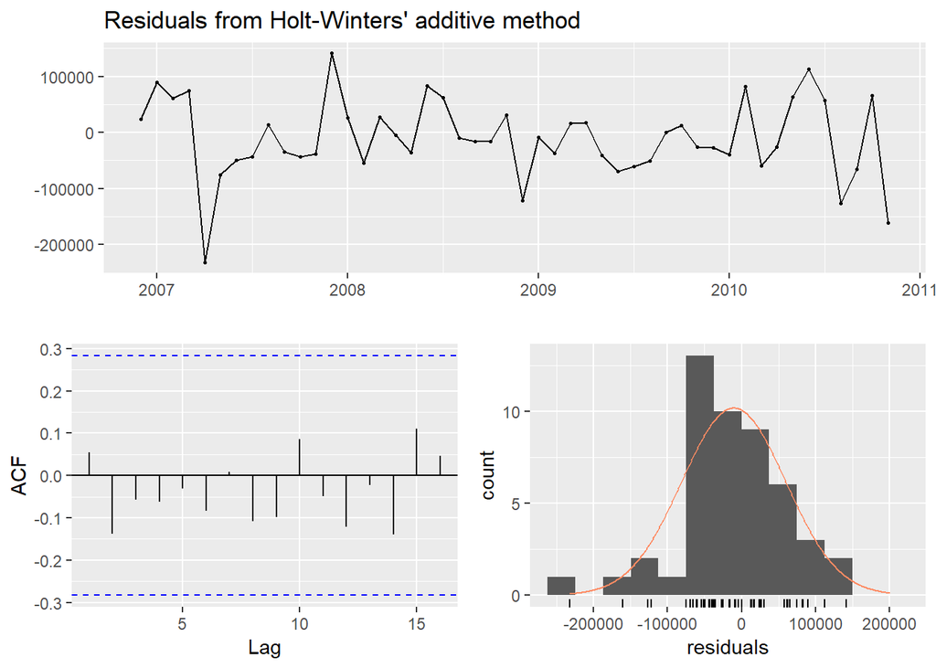

```
##
##  Ljung-Box test
##
## data:  Residuals from Holt-Winters' additive method
## Q* = 7.4178, df = 3, p-value = 0.05971
##
## Model df: 16.   Total lags used: 19
```

```r
checkresiduals(fit1)
```

```r
summary(fit1)
```

```
##
## Forecast method: Holt-Winters' additive method
##
## Model Information:
## Holt-Winters' additive method
##
## Call:
##  hw(y = pMonthClean, seasonal = "additive")
##
##   Smoothing parameters:
##     alpha = 0.0105
##     beta  = 0.0105
##     gamma = 0.0001
##
##   Initial states:
##     l = 814631.6636
##     b = 670.1522
##     s = 152114.7 45136.92 -88042.09 -266557.8 -284477.4 -179892
##            -16102.47 -7001.806 85039.38 61902.68 244273 253606.9
##
##   sigma:  86410.09
##
##      AIC     AICc      BIC
## 1291.574 1311.974 1323.384
##
## Error measures:
##                     ME     RMSE      MAE       MPE     MAPE      MASE
## Training set -10658.52 70553.54 54865.83 -2.515198 7.725927 0.6989853
##                    ACF1
## Training set 0.05531268
##
## Forecasts:
##          Point Forecast    Lo 80     Hi 80    Lo 95     Hi 95
## Dec 2010       999310.3 888571.3 1110049.2 829949.6 1168670.9
## Jan 2011       985277.6 874514.1 1096041.0 815879.5 1154675.6
## Feb 2011       798201.6 687383.3  909020.0 628719.5  967683.7
## Mar 2011       816635.0 705719.0  927551.0 647003.6  986266.4
## Apr 2011       719859.6 608791.2  830928.0 549995.1  889724.0
## May 2011       706070.6 594783.2  817358.1 535871.1  876270.2
## Jun 2011       537593.7 426008.7  649178.7 366939.2  708248.2
## Jul 2011       428298.2 316325.8  540270.5 257051.3  599545.1
## Aug 2011       441494.9 329034.2  553955.6 269501.1  613488.7
## Sep 2011       615312.4 502251.7  728373.1 442401.0  788223.8
## Oct 2011       743800.9 630018.5  857583.4 569785.7  917816.2
## Nov 2011       846053.7 731418.2  960689.2 670733.8 1021373.5
## Dec 2011       942862.9 827232.9 1058493.0 766022.0 1119703.8
## Jan 2012       928830.2 812059.0 1045601.4 750244.0 1107416.4
## Feb 2012       741754.3 623686.6  859821.9 561185.4  922323.2
## Mar 2012       760187.7 640662.1  879713.3 577389.1  942986.3
## Apr 2012       663412.2 542261.8  784562.6 478128.7  848695.8
## May 2012       649623.3 526676.9  772569.8 461592.9  837653.7
## Jun 2012       481146.4 356229.2  606063.6 290102.0  672190.7
## Jul 2012       371850.8 244785.7  498916.0 177521.5  566180.2
## Aug 2012       385047.6 255655.6  514439.5 187159.7  582935.5
## Sep 2012       558865.1 426966.7  690763.5 357143.9  760586.2
## Oct 2012       687353.6 552769.1  821938.1 481524.4  893182.8
## Nov 2012       789606.3 652156.8  927055.9 579395.3  999817.3
```

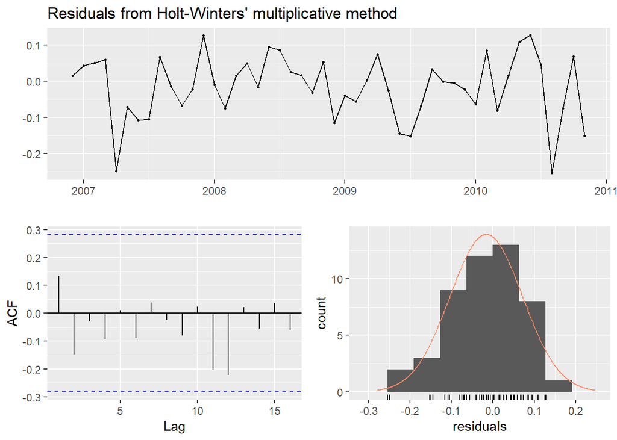

```
##
##  Ljung-Box test
##
## data:  Residuals from Holt-Winters' multiplicative method
## Q* = 10.428, df = 3, p-value = 0.01526
##
## Model df: 16.   Total lags used: 19
```

```r
checkresiduals(fit2)
```

```r
summary(fit2)
```

```
##
## Forecast method: Holt-Winters' multiplicative method
##
## Model Information:
## Holt-Winters' multiplicative method
##
## Call:
##  hw(y = pMonthClean, seasonal = "multiplicative")
##
##   Smoothing parameters:
##     alpha = 0.0103
##     beta  = 0.0102
##     gamma = 0.0002
##
##   Initial states:
##     l = 816806.715
##     b = 1489.2467
##     s = 1.1656 1.0731 0.861 0.6481 0.6713 0.8067
##            0.9552 0.9431 1.1229 1.0915 1.3451 1.3165
##
##   sigma:  0.1081
##
##      AIC     AICc      BIC
## 1289.575 1309.975 1321.386
##
## Error measures:
##                  ME     RMSE      MAE     MPE     MAPE      MASE
## Training set -11362 65418.07 51901.09 -2.4964 7.364663 0.6612147
##                    ACF1
## Training set 0.05076774
##
## Forecasts:
##          Point Forecast    Lo 80     Hi 80    Lo 95     Hi 95
## Dec 2010       981070.4 845142.7 1116998.0 773186.9 1188953.8
## Jan 2011       995793.4 857796.0 1133790.7 784744.6 1206842.1
## Feb 2011       802729.7 691432.5  914026.8 632515.3  972944.0
## Mar 2011       820365.0 706522.2  934207.8 646257.5  994472.5
## Apr 2011       684408.7 589300.2  779517.2 538952.8  829864.6
## May 2011       688540.2 592663.3  784417.1 541909.1  835171.2
## Jun 2011       577560.3 496912.7  658207.9 454220.4  700900.2
## Jul 2011       477328.2 410431.9  544224.5 375019.1  579637.3
## Aug 2011       457672.9 393231.4  522114.4 359118.2  556227.7
## Sep 2011       603885.2 518363.9  689406.5 473091.7  734678.8
## Oct 2011       747397.7 640808.7  853986.8 584383.9  910411.6
## Nov 2011       806162.4 690231.6  922093.2 628861.5  983463.3
## Dec 2011       904113.4 772821.3 1035405.4 703319.5 1104907.2
## Jan 2012       917167.5 782476.7 1051858.3 711175.7 1123159.3
## Feb 2012       738927.9 629018.3  848837.5 570835.7  907020.2
## Mar 2012       754726.8 640844.5  868609.2 580558.9  928894.8
## Apr 2012       629280.9 532799.8  725762.0 481725.8  776836.1
## May 2012       632704.8 533979.2  731430.5 481717.0  783692.7
## Jun 2012       530405.9 446041.0  614770.9 401380.9  659431.0
## Jul 2012       438090.2 366949.0  509231.4 329289.1  546891.3
## Aug 2012       419791.2 350087.9  489494.5 313189.2  526393.1
## Sep 2012       553554.3 459436.3  647672.3 409613.2  697495.3
## Oct 2012       684670.0 565303.1  804037.0 502114.1  867226.0
## Nov 2012       738026.1 605919.5  870132.8 535986.4  940065.9
```

Next, I use hte ets() function to select the best model.

```r
fit3 <- ets(pMonthClean)
summary(fit3)
```

```
## ETS(M,N,M)
##
## Call:
##  ets(y = pMonthClean)
##
##   Smoothing parameters:
##     alpha = 0.1031
##     gamma = 0.0001
##
##   Initial states:
##     l = 815833.2084
##     s = 1.1394 1.0722 0.8666 0.6385 0.6668 0.7934
##            0.9691 0.9565 1.1239 1.1018 1.347 1.3248
##
##   sigma:  0.1063
##
##      AIC     AICc      BIC
## 1286.702 1301.702 1314.770
##
## Training set error measures:
##                     ME     RMSE      MAE      MPE     MAPE      MASE
## Training set -10605.73 67593.29 52480.35 -2.35708 7.348373 0.6685944
##                    ACF1
## Training set 0.03092476
```

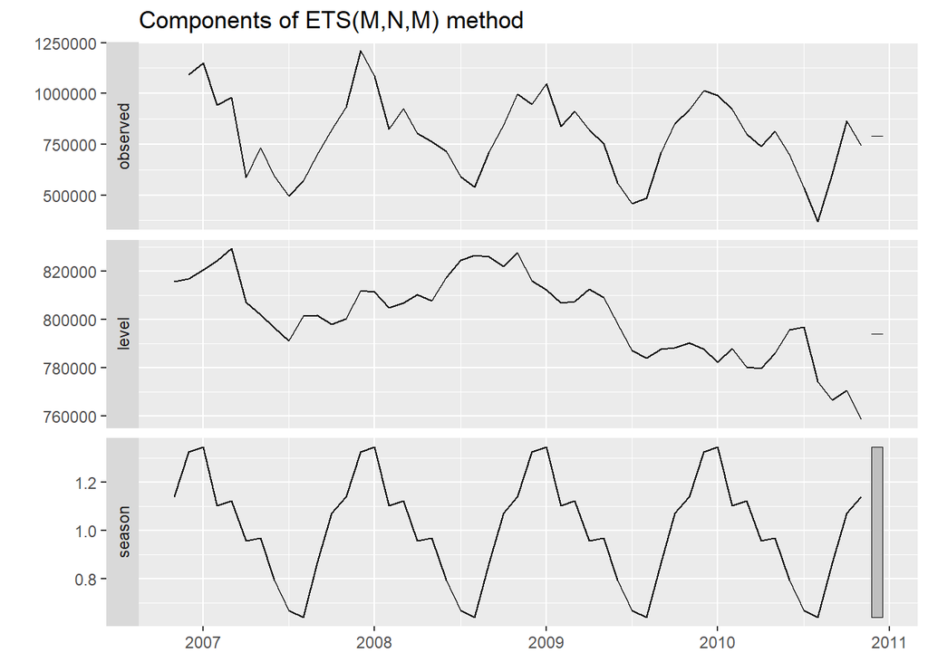

```r
autoplot(fit3)
```

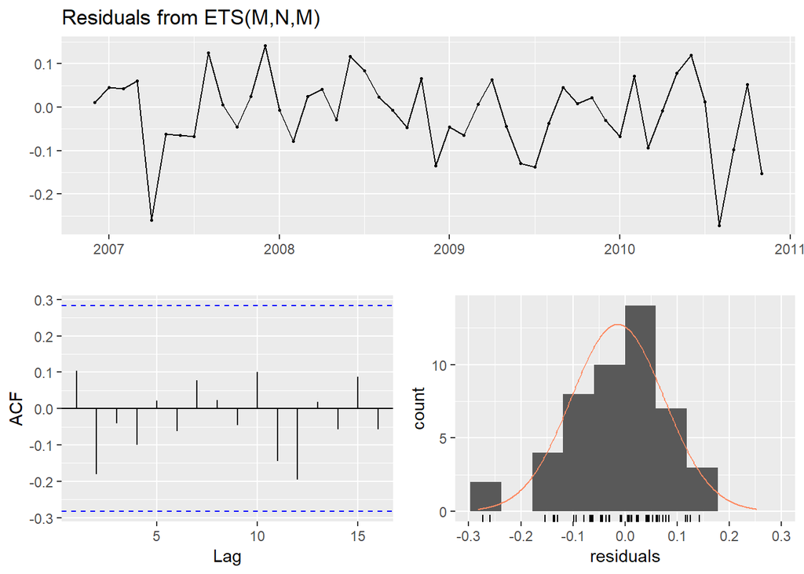

```
##
##  Ljung-Box test
##
## data:  Residuals from ETS(M,N,M)
## Q* = 9.3043, df = 3, p-value = 0.02551
##
## Model df: 14.   Total lags used: 17
```

```r
checkresiduals(fit3)
```

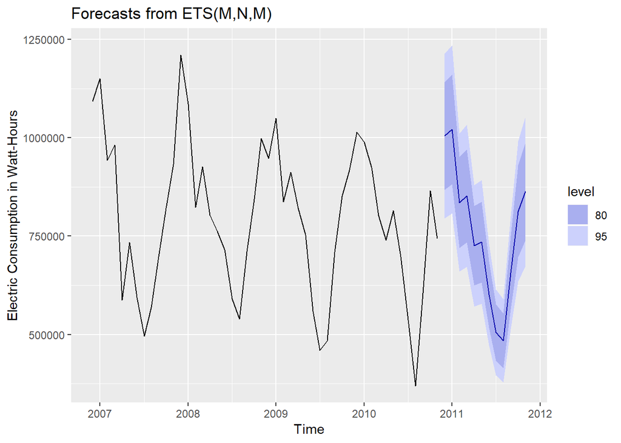

```r
fit3 %>% forecast(h=12) %>%
  autoplot() +
  ylab("Electric Consumption in Watt-Hours")
```

In the next section, I use the auto.arima function to select an appropriate ARIMA model.

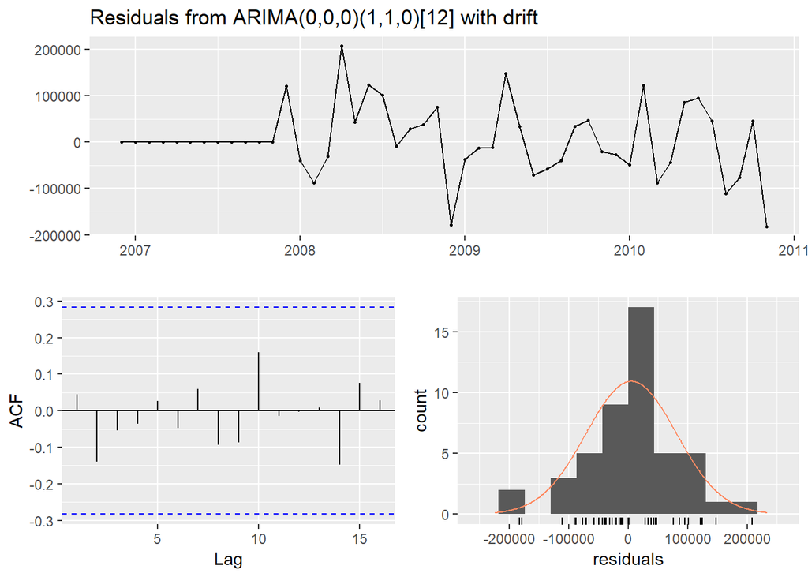

```
##
##  Ljung-Box test
##
## data:  Residuals from ARIMA(0,0,0)(1,1,0)[12] with drift
## Q* = 2.6938, df = 7.6, p-value = 0.9385
##
## Model df: 2.   Total lags used: 9.6
```

```r
fit4 <- auto.arima(pMonthClean)
checkresiduals(fit4)
```

```r
summary(fit4)
```

```
## Series: pMonthClean
## ARIMA(0,0,0)(1,1,0)[12] with drift
##
## Coefficients:
##          sar1       drift
##       -0.4689  -1658.2165
## s.e.   0.1738    944.7054
##
## sigma^2 estimated as 8071923054:  log likelihood=-462.15
## AIC=930.3   AICc=931.05   BIC=935.05
##
## Training set error measures:
##                    ME     RMSE      MAE       MPE     MAPE      MASE
## Training set 4986.642 75614.89 53788.89 0.1310408 7.277021 0.6852651
##                    ACF1
## Training set 0.04558863
```

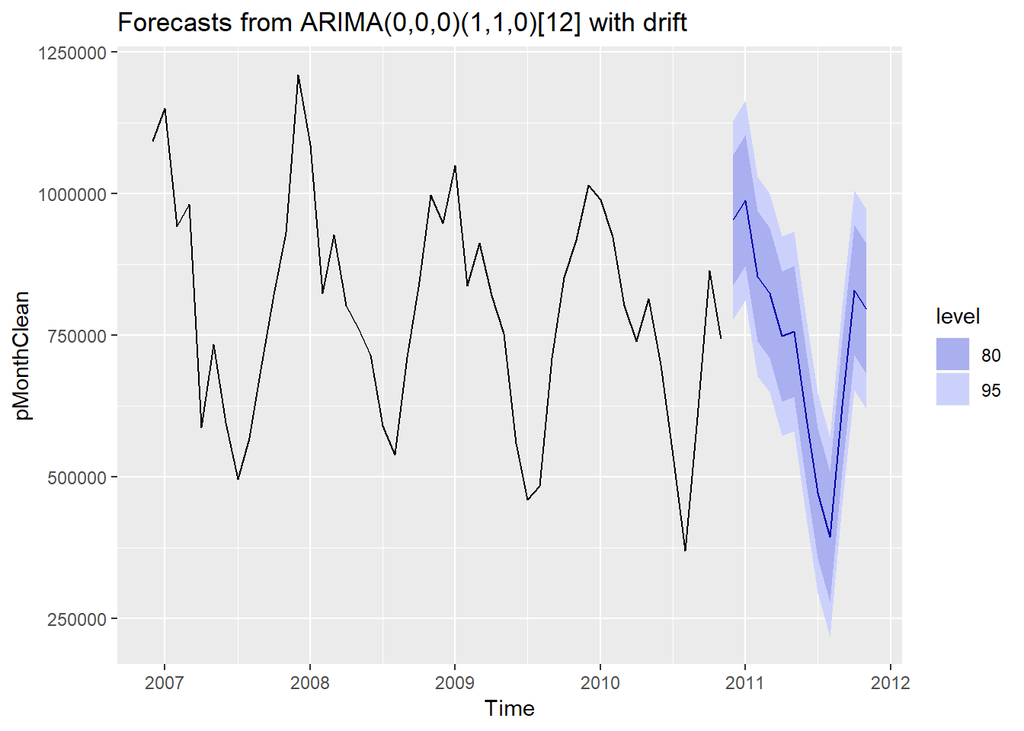

```r
autoplot(forecast(fit4, h=12))
```